# İzmir Genelinde Seçim Sonuçları

secimler R paketi otomatik raporlama

2017-02-23

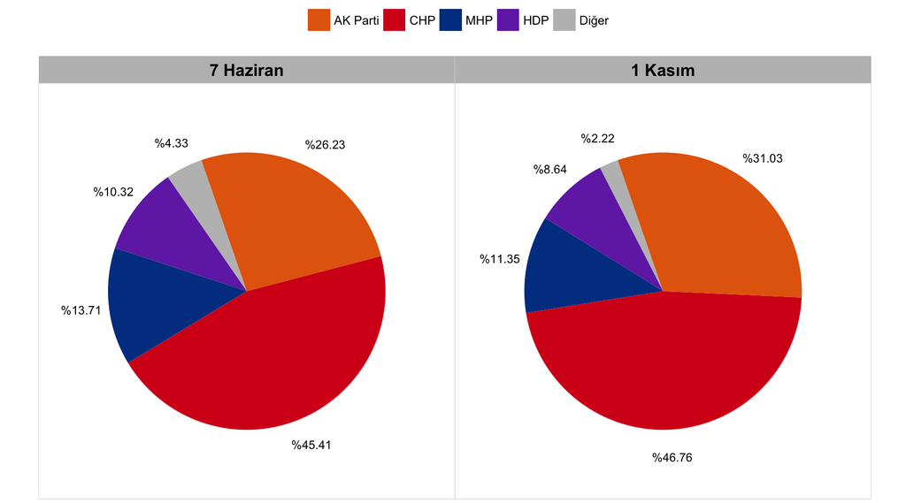

7 Haziran ve 1 Kasım 2015 genel seçimlerinin oy oranı bazında karşılaştırması.

# 7 Haziran 2015 Genel Seçimi Özet Bilgiler

İzmir ilinde bu seçimde 2 seçim bölgesi 30 ilçe, 1294 mahalle, 9 cezaevi ve toplamda 8.982 seçim sandığı bulunmaktadır. İl içerisinde toplam 3.085.404 kayıtlı seçmen bulunmaktadır. 2.697.497 seçmen oy kullanmış, geçerli oy sayısı ise 2.647.364 olmuştur. Seçime katılım oranı %87,43 olarak gerçekleşmiştir.

Toplam sonuçlarda AK Parti %26,23, CHP %45,41, MHP %13,71, HDP %10,32 ve diğer partiler ile bağımsızlar %4,33 oy oranına sahip olmuşlardır. İzmir, 81 il arasından, partilerin kendi içindeki oy oranları sıralamalarına göre AK Parti’nin 67, CHP’nin 4, MHP’nin 62 ve HDP’nin 24. sıradaki ili olmuştur.[^1]

İzmir 1. bölge Balçova, Buca, Çeşme, Gaziemir, Güzelbahçe, Karabağlar, Karaburun, Konak, Menderes, Narlıdere, Seferihisar, Selçuk, Torbalı ve Urla ilçelerini kapsamaktadır.Bu bölgede 14 ilçe, 484 mahalle, 4 cezaevi ve toplamda 4.304 seçim sandığı bulunmaktadır. Seçim bölgesi içerisinde toplam 1.513.998 kayıtlı seçmen bulunmaktadır. 1.312.609 seçmen oy kullanmış, geçerli oy sayısı ise 1.287.223 olmuştur. Seçime katılım oranı %86,7 olarak gerçekleşmiştir.

Toplam sonuçlarda AK Parti %26,05, CHP %44,47, MHP %12,82, HDP %11,48 ve diğer partiler ile bağımsızlar %5,18 oy oranına sahip olmuşlardır.

İzmir 2. bölge Aliağa, Bayındır, Bayraklı, Bergama, Beydağ, Bornova, Çiğli, Dikili, Foça, Karşıyaka, Kemalpaşa, Kiraz, Kınık, Menemen, Ödemiş ve Tire ilçelerini kapsamaktadır.Bu bölgede 16 ilçe, 810 mahalle, 5 cezaevi ve toplamda 4.678 seçim sandığı bulunmaktadır. Seçim bölgesi içerisinde toplam 1.571.406 kayıtlı seçmen bulunmaktadır. 1.384.888 seçmen oy kullanmış, geçerli oy sayısı ise 1.360.141 olmuştur. Seçime katılım oranı %88,13 olarak gerçekleşmiştir.

Toplam sonuçlarda AK Parti %26,39, CHP %46,3, MHP %14,56, HDP %9,22 ve diğer partiler ile bağımsızlar %3,53 oy oranına sahip olmuşlardır.

İl içerisinde sandık bazında partilere oy oranı dağılımı aşağıdaki grafikte gösterilmiştir. Kutu grafiğini yorumlamak için orta çizgi ortanca (medyan), alt ve üst çizgiler sırasıyla %25 ve %75lik dilimler ve noktalar da uç değerleri (outlier) göstermektedir. *(Örneğin bir partinin grafiğinin orta çizgisi %40 değerindeyse, sandıkların yarısında %40 ve üzeri, diğer yarısında ise %40 altı oy oranı var demektir.)*

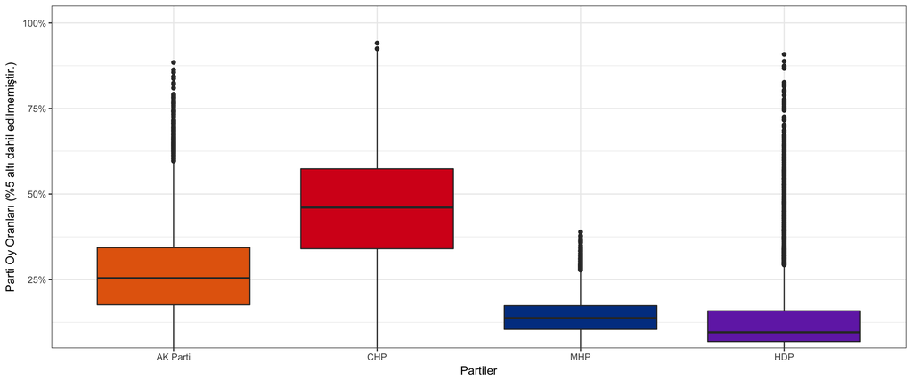

7 Haziran seçimlerinde partilerin seçim çevrelerinden aldıkları oy oranları kutu grafiği.

# 1 Kasım 2015 Genel Seçimi Özet Bilgiler

İzmir ilinde bu seçimde 2 seçim bölgesi 30 ilçe, 1294 mahalle, 11 cezaevi ve toplamda 9.031 seçim sandığı bulunmaktadır. İl içerisinde toplam 3.104.343 kayıtlı seçmen bulunmaktadır. 2.735.354 seçmen oy kullanmış, geçerli oy sayısı ise 2.704.306 olmuştur. Seçime katılım oranı %88,11 olarak gerçekleşmiştir.

Toplam sonuçlarda AK Parti %31,03, CHP %46,76, MHP %11,35, HDP %8,64 ve diğer partiler ile bağımsızlar %2,22 oy oranına sahip olmuşlardır. İzmir, 81 il arasından, partilerin kendi içindeki oy oranları sıralamalarına göre AK Parti’nin 69, CHP’nin 4, MHP’nin 51 ve HDP’nin 24. sıradaki ili olmuştur.[^2]

İzmir 1. bölge Balçova, Buca, Çeşme, Gaziemir, Güzelbahçe, Karabağlar, Karaburun, Konak, Menderes, Narlıdere, Seferihisar, Selçuk, Torbalı ve Urla ilçelerini kapsamaktadır.Bu bölgede 14 ilçe, 484 mahalle, 4 cezaevi ve toplamda 4.325 seçim sandığı bulunmaktadır. Seçim bölgesi içerisinde toplam 1.521.967 kayıtlı seçmen bulunmaktadır. 1.330.210 seçmen oy kullanmış, geçerli oy sayısı ise 1.315.403 olmuştur. Seçime katılım oranı %87,4 olarak gerçekleşmiştir.

Toplam sonuçlarda AK Parti %30,89, CHP %45,8, MHP %11,32, HDP %9,84 ve diğer partiler ile bağımsızlar %2,14 oy oranına sahip olmuşlardır.

İzmir 2. bölge Aliağa, Bayındır, Bayraklı, Bergama, Beydağ, Bornova, Çiğli, Dikili, Foça, Karşıyaka, Kemalpaşa, Kiraz, Kınık, Menemen, Ödemiş ve Tire ilçelerini kapsamaktadır.Bu bölgede 16 ilçe, 810 mahalle, 7 cezaevi ve toplamda 4.706 seçim sandığı bulunmaktadır. Seçim bölgesi içerisinde toplam 1.582.376 kayıtlı seçmen bulunmaktadır. 1.405.144 seçmen oy kullanmış, geçerli oy sayısı ise 1.388.903 olmuştur. Seçime katılım oranı %88,8 olarak gerçekleşmiştir.

Toplam sonuçlarda AK Parti %31,15, CHP %47,67, MHP %11,38, HDP %7,51 ve diğer partiler ile bağımsızlar %2,29 oy oranına sahip olmuşlardır.

İl içerisinde sandık bazında partilere oy oranı dağılımı aşağıdaki grafikte gösterilmiştir. Kutu grafiğini yorumlamak için orta çizgi ortanca (medyan), alt ve üst çizgiler sırasıyla %25 ve %75lik dilimler ve noktalar da uç değerleri (outlier) göstermektedir. *(Örneğin bir partinin grafiğinin orta çizgisi %40 değerindeyse, sandıkların yarısında %40 ve üzeri, diğer yarısında ise %40 altı oy oranı var demektir.)*

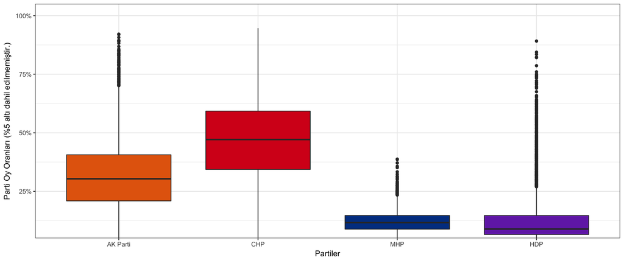

1 Kasım seçimlerinde partilerin seçim çevrelerinden aldıkları oy oranları kutu grafiği.

# Oy Kaymaları

7 Haziran ve 1 Kasım arasında partiler arasında oy kaymaları yaşanmıştır. Bu oy kaymaları seçim birimi bazındaki oy oranı değişimlerinin incelenmesi sonucu hesaplanmaktadır. Aşağıdaki tablolarda partiler arasındaki oy kaymaları verilmektedir. Tablolardaki oy kaymalarını incelerken lütfen aşağıdaki maddelere dikkat ediniz.

- Oy kaymaları satırdan sütuna okunmalıdır.
- Oy kaymaları puan bazındadır. Örneğin MHP’den AK Parti’ye %10 bir kayma; MHP’nin oylarının %10’unu değil, bütün oyların bir önceki seçimde MHP’ye ait olan %10luk kesimini belirtmektedir.
- Partilerin farklı sandıklarda oy oranları farklı şekillerde değiştiğinden iki partiden de birbirlerine oy kayması mümkün olabilir. Net oy kayması ayrı bir tabloda verilmiştir.
- Partiler arasında zincir olarak oy kayması yaşanmış olabilir. Örneğin MHP’den CHP’ye net oy kayması yaşanırken, CHP’den de AK Parti’ye net oy kayması yaşanmış olabilir.

Partiler arasındaki oy oranı kaymaları.

|  | AK Parti | CHP | MHP | HDP | Diğer |
| --- | --- | --- | --- | --- | --- |
| AK Parti | 0 | %0.01 | %0 | %0 | %0 |
| CHP | %0.35 | 0 | %0.01 | %0.01 | %0.01 |
| MHP | %1.73 | %0.69 | 0 | %0.01 | %0.01 |
| HDP | %1.22 | %0.43 | %0.01 | 0 | %0 |
| Diğer | %1.53 | %0.57 | %0.03 | %0 | 0 |

Partiler arasındaki net oy oranı kaymaları.

|  | AK Parti | CHP | MHP | HDP | Diğer |
| --- | --- | --- | --- | --- | --- |
| AK Parti | %0 | %0 | %0 | %0 | %0 |
| CHP | %0.34 | %0 | %0 | %0 | %0 |
| MHP | %1.73 | %0.68 | %0 | %0 | %0 |
| HDP | %1.22 | %0.42 | %0 | %0 | %0 |
| Diğer | %1.53 | %0.57 | %0.02 | %0 | %0 |

# İlçe Bazında Karşılaştırmalar

Aşağıdaki bilgilerde ilçe bazında özet grafikler bulunmaktadır. Bu grafiklerde her ilçenin toplam kayıtlı seçmen sayısı, geçerli oy sayısı, geçersiz oy sayısı ve barajı aşan partilerin (AK Parti, CHP, MHP ve HDP) oy oranları bulunmaktadır. İlçeler hakkında detaylı bilgi edinmek için ilçelerin kendi raporlarını inceleyebilirsiniz. *(Detaylı bilgi dökümanın sonunda yer almaktadır.)*

## Seçmen İstatistikleri

Kayıtlı seçmen sayısındaki değişim en yüksek oranda Menemen (+%2.34) ilçesinde ve en düşük oranda Konak (-%0.5) ilçesinde görülmektedir. Seçime katılım oranında değişim ise en yüksek oranda Kemalpaşa (+%1.36) ilçesinde ve en düşük oranda Dikili (-%1.71) ilçesinde görülmektedir.

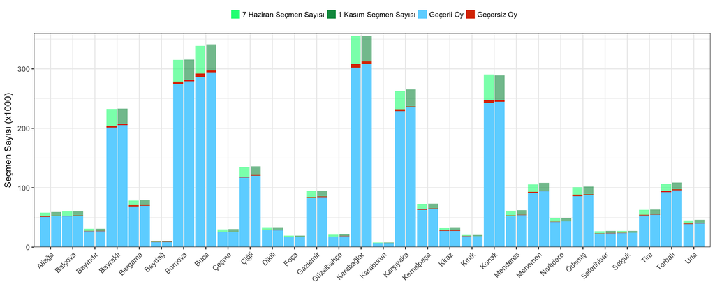

İlçelerin kayıtlı seçmen, geçerli ve geçersiz oy sayıları.

## Parti Oy Oranları

### AK Parti

AK Parti, 7 Haziran seçimlerinde İzmir ilçeleri arasında en yüksek oy oranını Kiraz (%42.1), en düşük oy oranını Narlıdere (%12.79) ilçelerinde görmüştür. 1 Kasım seçimlerinde ise en yüksek oy oranını Kiraz (%48.16), en düşük oy oranını Narlıdere (%14.82) ilçelerinde görmüştür. Parti bütün ilçelerde oy oranlarını yükseltmiştir. Puan bazında en büyük yükseliş Torbalı ilçesinde (+%8.01) görülmektedir.

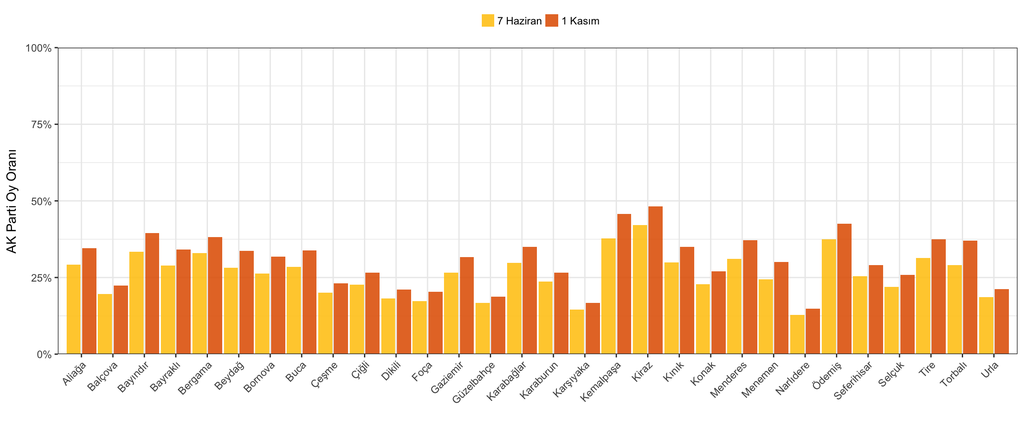

AK Parti’nin ilçelerde aldığı oy oranları.

### CHP

CHP, 7 Haziran seçimlerinde İzmir ilçeleri arasında en yüksek oy oranını Karşıyaka (%63.47), en düşük oy oranını Torbalı (%34.85) ilçelerinde görmüştür. 1 Kasım seçimlerinde ise en yüksek oy oranını Karşıyaka (%66.52), en düşük oy oranını Kemalpaşa (%34.85) ilçelerinde görmüştür. Puan bazında en büyük yükseliş Foça ilçesinde (+%3.69) görülmektedir. Puan bazında en büyük düşüş ise Bayındır ilçesinde (-%3.12) görülmektedir.

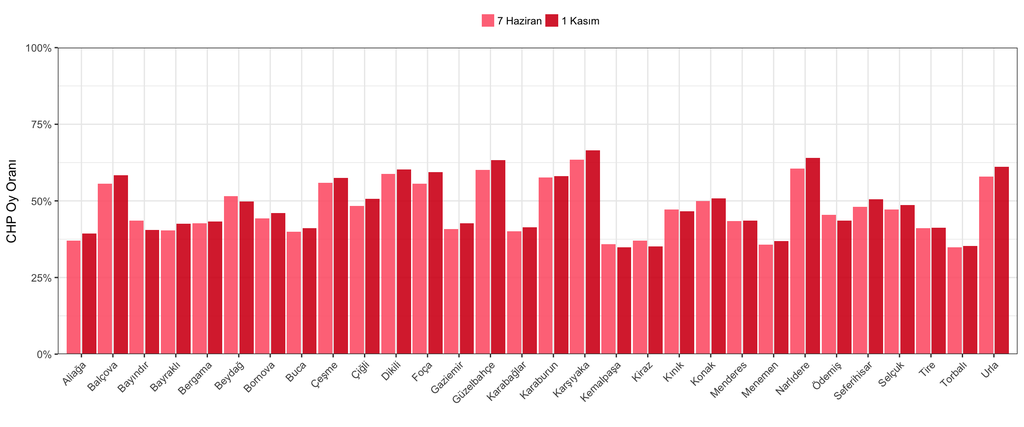

CHP’nin ilçelerde aldığı oy oranları.

### MHP

MHP, 7 Haziran seçimlerinde İzmir ilçeleri arasında en yüksek oy oranını Tire (%19.77), en düşük oy oranını Narlıdere (%8.62) ilçelerinde görmüştür. 1 Kasım seçimlerinde ise en yüksek oy oranını Tire (%15.38), en düşük oy oranını Narlıdere (%7.17) ilçelerinde görmüştür. Parti hiçbir ilçede oy oranını yükseltememiştir. Puan bazında en büyük düşüş Aliağa ilçesinde (-%4.43) görülmektedir.

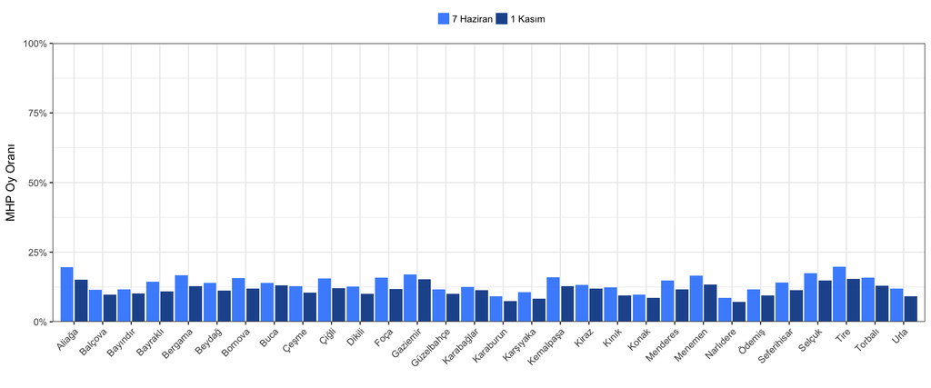

MHP’nin ilçelerde aldığı oy oranları.

### HDP

HDP, 7 Haziran seçimlerinde İzmir ilçeleri arasında en yüksek oy oranını Menemen (%20.35), en düşük oy oranını Beydağ (%0.65) ilçelerinde görmüştür. 1 Kasım seçimlerinde ise en yüksek oy oranını Menemen (%17.58), en düşük oy oranını Beydağ (%0.29) ilçelerinde görmüştür. Parti hiçbir ilçede oy oranını yükseltememiştir. Puan bazında en büyük düşüş Menemen ilçesinde (-%2.77) görülmektedir.

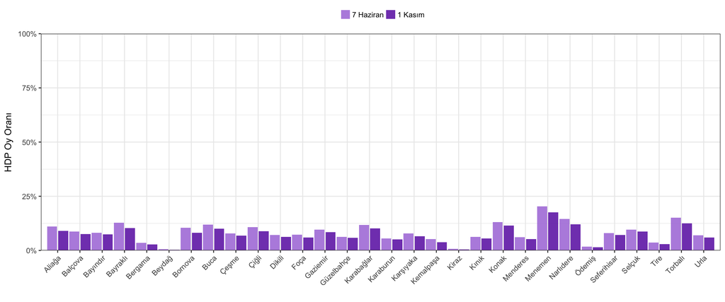

HDP’nin ilçelerde aldığı oy oranları.

# Bilinmesi Gerekenler

- Bu döküman otomatik olarak oluşturulmuştur.
- Dökümanın amacı R ile veri analizi, görselleştirme ve otomatik raporlama konusunda bir eğitim örneği oluşturmaktır.
- Bu dökümanı oluşturmakta kullanılan veriler 7 Haziran ve 1 Kasım’a ait sandık bazında seçim sonucu verilerinden oluşmaktadır. Veriler TÜİK vasıtasıyla YSK kesin seçim sonuçlarından elde edilmiştir.
- Veriler veya hesaplamalarda yanlışlıklar olabilir. Veriler ve analizlerle ilgili herhangi bir sorumluluk kabul edilmemektedir.
- İlgili veri setleri ve analizlere `secimler` R paketi vasıtasıyla ulaşılabilir. Paket hala geliştirme aşamasında olup sürekli güncellenmektedir. https://github.com/berkorbay/secimler adresinden pakete ulaşılabilir ve yükleme talimatları görülebilir.
- Paketin yazarına (Berk Orbay) http://berkorbay.me adresinden ulaşabilirsiniz.
[^1]: Örneğin, AK Parti 66 ilde daha yüksek, 14 ilde ise daha düşük oy oranı görmüştür.
[^2]: Örneğin, AK Parti 68 ilde daha yüksek, 12 ilde ise daha düşük oy oranı görmüştür.